# Assign3

Importing required libraries

```python
import numpy as np
import pandas as pd
import matplotlib.pyplot as plt
import tensorflow as tf
from tensorflow import keras
```

**PART-1**

Loading dataset for standardization and train test split.

```python
conc_dataset = pd.read_csv("drive/MyDrive/SEIS764/Assignments/Assignment3/concrete.csv")
X = conc_dataset.iloc[:,:-1]
y = conc_dataset.iloc[:,8]

# 70-30 train test split
from sklearn.model_selection import train_test_split
X_train, X_test, y_train, y_test = train_test_split(X,y,test_size=0.3,random_state=0)

# Normalization using standardization
from sklearn.preprocessing import StandardScaler
sc = StandardScaler()
X_train = sc.fit_transform(X_train)
X_test = sc.transform(X_test)
```

*MODEL-1*

- Layers: 2 (Layer1-1 unit, Layer2-2 units)
- Activation function: relu
- Optimizer: adam
- Epochs: 200

```
Model evaluation:
```

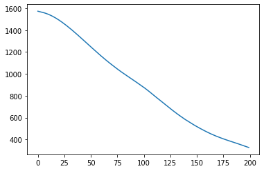

```python
# Model instantiation
model1 = tf.keras.Sequential([
    keras.layers.Dense(units = 1, input_shape=[8],activation='relu'),
    keras.layers.Dense(2)
])

# Model compilation
model1.compile(
   optimizer = 'adam', loss = 'mean_squared_error'
)

# Model fitting
r = model1.fit(X_train, y_train, validation_data = (X_test, y_test), epochs = 200)

print("\nModel evaluation:")
# Model evaluation
model1.evaluate(X_test, y_test)

# Loss plot
plt.plot(r.history['loss'])
```

*MODEL-2*

- Layers: 2 (Layer1-2 units, Layer2-2 units)
- Optimizer: sgd (momentum-0.9 and learning rate-0.001)
- Epochs: 200

```
Model evaluation:
```

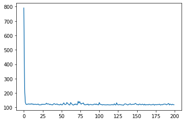

```python
# Model instantiation
model2 = tf.keras.Sequential([
    keras.layers.Dense(units = 2, input_shape=[8]),
    keras.layers.Dense(2)
])

# Model compilation
model2.compile(
   optimizer=tf.keras.optimizers.SGD(0.001,0.9), loss = 'mean_squared_error'
)

# Model fitting
r = model2.fit(X_train, y_train, validation_data = (X_test, y_test), epochs = 200)

print("\nModel evaluation:")
# Model evaluation
model2.evaluate(X_test, y_test)

# Loss plot
plt.plot(r.history['loss'])
```

*MODEL-3*

- Layers: 3 (Layer1 - 2 units, Layer2 - 2 units, Layer3 - 3 units)
- Activation function: relu
- Optimizer: sgd (momentum-0.9 and learning rate-0.0001)
- Epochs: 200

```
Model evaluation:
```

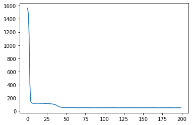

```python
# Model instantiation
model3 = tf.keras.Sequential([
    keras.layers.Dense(units = 2, input_shape=[8],activation='relu'),
    keras.layers.Dense(2),
    keras.layers.Dense(3)
])

# Model compilation
model3.compile(
   optimizer=tf.keras.optimizers.SGD(0.0001,0.9), loss = 'mean_squared_error'
)

# Model fitting
r = model3.fit(X_train, y_train, validation_data = (X_test, y_test), epochs = 200)

print("\nModel evaluation:")
# Model evaluation
model3.evaluate(X_test, y_test)

# Loss plot
plt.plot(r.history['loss'])
```

*MODEL-4*

- Layers: 3 (Layer1 - 2 units, Layer2 - 2 units, Layer3 - 3 units)
- Activation function: relu
- Optimizer: sgd (momentum-0.9 and learning rate-0.001)
- Epochs: 200

```
Model evaluation:
```

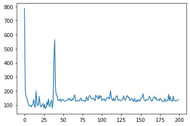

```python
# Model instantiation
model4 = tf.keras.Sequential([
    keras.layers.Dense(units = 2, input_shape=[8],activation='relu'),
    keras.layers.Dense(2),
    keras.layers.Dense(3)
])

# Model compilation
model4.compile(
   optimizer=tf.keras.optimizers.SGD(0.001,0.9), loss = 'mean_squared_error'
)

# Model fitting
r = model4.fit(X_train, y_train, validation_data = (X_test, y_test), epochs = 200)

print("\nModel evaluation:")
# Model evaluation
model4.evaluate(X_test, y_test)

# Loss plot
plt.plot(r.history['loss'])
```

*MODEL-5*

- Layers: 3 (Layer1 - 2 units, Layer2 - 3 units, Layer3 - 1 unit)
- Activation function: relu
- Optimizer: rmsprop
- Epochs: 200

```
Model evaluation:
```

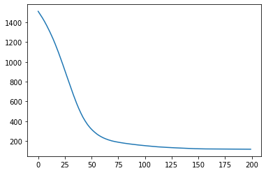

```python
# Model instantiation
model4 = tf.keras.Sequential([
    keras.layers.Dense(units = 2, input_shape=[8],activation='relu'),
    keras.layers.Dense(3),
    keras.layers.Dense(1)
])

# Model compilation
model4.compile(
   optimizer='rmsprop', loss = 'mean_squared_error'
)

# Model fitting
r = model4.fit(X_train, y_train, validation_data = (X_test, y_test), epochs = 200)

print("\nModel evaluation:")
# Model evaluation
model4.evaluate(X_test, y_test)

# Loss plot
plt.plot(r.history['loss'])
```

*Loss Summary*

- MODEL-1 gives loss: 282.8987
- MODEL-2 gives loss: 93.1422
- MODEL-3 gives loss: 48.1766
- MODEL-4 gives loss: 94.4270
- MODEL-5 gives loss: 94.917

Model-3 performs best as it gives minimum loss at 48.17. In comparison to adam and rmsprop optimizers, stochaistic gradient descent adapts to learning the training dataset well. Further, sgd with low learning rate of 0.0001 learns fast and better as compared to sgd with 0.001 learning rate in model-4. The addition of layer3 with 3 units minimizes the loss but increases the complexity slightly.

*PART-2*

Loading customer.csv for preprocessing and normalization.

```python
#Loading the dataset
dataset = pd.read_csv('drive/My Drive/SEIS764/customers.csv')

X = dataset.iloc[:,3:13].values
y = dataset.iloc[:,13].values

# Encoding categorical data
# Encoding the Independent Variable

from sklearn.preprocessing import LabelEncoder, OneHotEncoder

#Label Encoding Gender
labelencoder_X = LabelEncoder()
X[:, 2] = labelencoder_X.fit_transform(X[:, 2])

#Dealing with the categorical Geography column
from sklearn.compose import make_column_transformer
onehotencoder = make_column_transformer((OneHotEncoder(), [1]), remainder='passthrough')
X = onehotencoder.fit_transform(X)

#Removing the extra dummy variable
X = X[:, 1:]

#Splitting the data into Training Set and Test Set
from sklearn.model_selection import train_test_split
X_train, X_test, y_train, y_test = train_test_split(X,y,test_size=0.2,random_state=0)

#Normalizing the features
from sklearn.preprocessing import StandardScaler
sc_X = StandardScaler()
X_train = sc_X.fit_transform(X_train)
X_test = sc_X.transform(X_test)
```

Building a neural network with with 2 hidden layers (with relu) and one unit output layer (with sigmoid).

```python
# Define the model
model = tf.keras.models.Sequential()

# Adding the first layer
model.add(tf.keras.layers.Dense(units=6, input_shape=[11],activation='relu'))

#Adding a second hidden layer
model.add(tf.keras.layers.Dense(units=6, activation='relu'))

#Adding an output layer
model.add(tf.keras.layers.Dense(units=1, activation='sigmoid'))

model.compile(optimizer='adam',
              loss='binary_crossentropy',
              metrics=['accuracy'])

# Train the model
r = model.fit(X_train, y_train, validation_data=(X_test, y_test), epochs=100)
```

Model Evaluation

```python
# Evaluate the model, prints loss and accuracy
print("Train score:", model.evaluate(X_train, y_train))
print("Test score:", model.evaluate(X_test, y_test))
```

```
Train score: [0.32875049114227295, 0.8652499914169312]
Test score: [0.3312479257583618, 0.8585000038146973]
```

Predicting customer class (Left=0 or 1) for the customer with following details:

- Credit Score: 600
- Geography: France
- Gender: Male
- Age: 40 years old
- Tenure: 3 years
- Balance: 60000 USD
- Number of Products: 2
- Does this customer have a credit card ? Yes
- Is this customer an Active Member: Yes
- Estimated Salary: $50000

```python
#Passing 1 for gender as per labelenvoding
#Passing 1 for HasCrCard
#Passing 1 for IsActiveMember
X_new = np.array([600,'France',1,40,3,60000,2,1,1,50000])

# Onehotencoding for country column
X_new = onehotencoder.transform(X_new.reshape(1,-1))

# Dropping extra dummy variable
X_new = X_new[:, 1:]

# Standardizing features
X_new = sc_X.transform(X_new)

# Predicting using existing model
y_new = model.predict(X_new)
y_new = np.round(y_new.flatten())
print(y_new)
```

```
[0.]
```

This customer doesn't leave the bank as predicted class is 0.

*PART-3*

Loading onlinestore.csv dataset for preprocessing and model building.

```python
os_dataset = pd.read_csv("drive/MyDrive/SEIS764/Assignments/Assignment3/onlineStore.csv")

os_dataset.head(5)
```

|  | is_mobile | n_products_viewed | visit_duration | is_returning_visitor | time_of_day | user_action |
| --- | --- | --- | --- | --- | --- | --- |
| 0 | 1 | 0 | 0.657510 | 0 | 3 | 0 |
| 1 | 1 | 1 | 0.568571 | 0 | 2 | 1 |
| 2 | 1 | 0 | 0.042246 | 1 | 1 | 0 |
| 3 | 1 | 1 | 1.659793 | 1 | 1 | 2 |
| 4 | 0 | 1 | 2.014745 | 1 | 1 | 2 |

Data Preprocessing and train-test split

```python
X = os_dataset.iloc[:,:-1]
y = os_dataset.iloc[:,5]

# Encoding categorical data
from sklearn.preprocessing import OneHotEncoder

#Dealing with the categorical Time_of_day column
from sklearn.compose import make_column_transformer
onehotencoder = make_column_transformer((OneHotEncoder(), [4]), remainder='passthrough')
X = onehotencoder.fit_transform(X)

#Removing the extra dummy variable
X = X[:, 1:]

#Splitting the data into Training Set and Test Set
from sklearn.model_selection import train_test_split
X_train, X_test, y_train, y_test = train_test_split(X,y,test_size=0.3,random_state=0)

#Normalizing the features (N_products_viewed and Visit_duration)
from sklearn.preprocessing import StandardScaler
sc_X = StandardScaler()
X_train = sc_X.fit_transform(X_train)
X_test = sc_X.transform(X_test)
```

Building deep NN for classifying user actions.

*MODEL-1*

- Layers: 3 (Layer1 - 6 units, Layer2 - 6 units, Layer3 - 4 unit)
- Activation function: relu (hidden layers), softmax (output layer)
- Optimizer: adam
- Epochs: 100

```python
# Define the model
model = tf.keras.models.Sequential()

# Adding the first layer
model.add(tf.keras.layers.Dense(units=6, input_shape=[7],activation='relu'))

#Adding a second hidden layer
model.add(tf.keras.layers.Dense(units=6, activation='relu'))

#Adding an output layer
model.add(tf.keras.layers.Dense(units=4, activation='softmax'))

model.compile(optimizer='adam',
              loss='sparse_categorical_crossentropy',
              metrics=['accuracy'])

# Train the model
r = model.fit(X_train, y_train, validation_data=(X_test, y_test), epochs=100)

#Evaluatethemodel
print("\nModel Evaluation")
print(model.evaluate(X_test,y_test))
```

```
Model Evaluation
[0.33229076862335205, 0.9066666960716248]
```

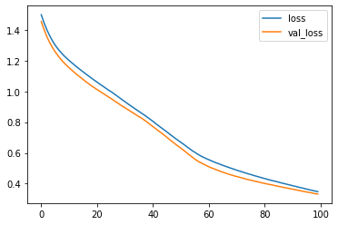

```python
#Plotlossperiteration
plt.plot(r.history['loss'],label='loss')
plt.plot(r.history['val_loss'],label='val_loss')
plt.legend()
```

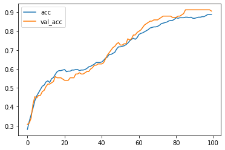

```python
#Plotaccuracyperiteration
plt.plot(r.history['accuracy'],label='acc')
plt.plot(r.history['val_accuracy'],label='val_acc')
plt.legend()
```

*MODEL-2*

- Layers: 3 (Layer1 - 6 units, Layer2 - 6 units, Layer3 - 4 unit)
- Activation function: relu (hidden layers), softmax (output layer)
- Adding dropout of 0.1 for layer2
- Optimizer: adam
- Epochs: 100

```python
# Define the model
model = tf.keras.models.Sequential()

# Adding the first layer
model.add(tf.keras.layers.Dense(units=6, input_shape=[7],activation='relu'))

#Adding a second hidden layer
model.add(tf.keras.layers.Dense(units=6, activation='relu'))
#Adding dropout of 0.1
model.add(tf.keras.layers.Dropout(0.1))
#Adding an output layer
model.add(tf.keras.layers.Dense(units=4, activation='softmax'))

model.compile(optimizer='adam',
              loss='sparse_categorical_crossentropy',
              metrics=['accuracy'])

# Train the model
r = model.fit(X_train, y_train, validation_data=(X_test, y_test), epochs=100)

#Evaluatethemodel
print("\nModel Evaluation")
print(model.evaluate(X_test,y_test))
```

```
Model Evaluation
[0.3705131411552429, 0.8866666555404663]
```

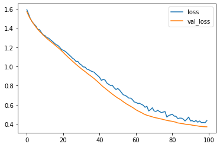

```python
#Plotlossperiteration
plt.plot(r.history['loss'],label='loss')
plt.plot(r.history['val_loss'],label='val_loss')
plt.legend()
```

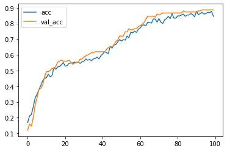

```python
#Plotaccuracyperiteration
plt.plot(r.history['accuracy'],label='acc')
plt.plot(r.history['val_accuracy'],label='val_acc')
plt.legend()
```

*MODEL-3*

- Layers: 3 (Layer1 - 6 units, Layer2 - 6 units, Layer3 - 4 unit)
- Activation function: relu (hidden layers), softmax (output layer)
- Adding dropout of 0.1 for layer2
- Optimizer: sgd
- Epochs: 100

```python
# Define the model
model = tf.keras.models.Sequential()

# Adding the first layer
model.add(tf.keras.layers.Dense(units=6, input_shape=[7],activation='relu'))

#Adding a second hidden layer
model.add(tf.keras.layers.Dense(units=6, activation='relu'))
#Adding dropout of 0.1
model.add(tf.keras.layers.Dropout(0.1))
#Adding an output layer
model.add(tf.keras.layers.Dense(units=4, activation='softmax'))

model.compile(optimizer='sgd',
              loss='sparse_categorical_crossentropy',
              metrics=['accuracy'])

# Train the model
r = model.fit(X_train, y_train, validation_data=(X_test, y_test), epochs=100)

#Evaluatethemodel
print("\nModel Evaluation")
print(model.evaluate(X_test,y_test))
```

```
Model Evaluation
[1.008426547050476, 0.5]
```

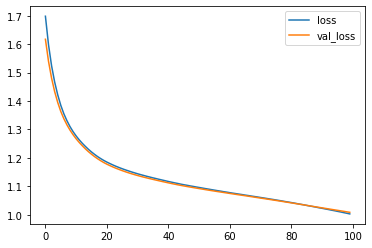

```python
#Plotlossperiteration
plt.plot(r.history['loss'],label='loss')
plt.plot(r.history['val_loss'],label='val_loss')
plt.legend()
```

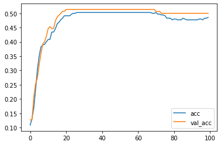

```python
#Plotaccuracyperiteration
plt.plot(r.history['accuracy'],label='acc')
plt.plot(r.history['val_accuracy'],label='val_acc')
plt.legend()
```

*MODEL-4*

- Layers: 3 (Layer1 - 6 units, Layer2 - 6 units, Layer3 - 4 unit)
- Activation function: relu (hidden layers), softmax (output layer)
- Optimizer: sgd (Learning rate:0.001 and momentum=0.9)
- Epochs: 100

```python
# Define the model
model = tf.keras.models.Sequential()

# Adding the first layer
model.add(tf.keras.layers.Dense(units=6, input_shape=[7],activation='relu'))

#Adding a second hidden layer
model.add(tf.keras.layers.Dense(units=6, activation='relu'))

#Adding an output layer
model.add(tf.keras.layers.Dense(units=4, activation='softmax'))

model.compile(optimizer=tf.keras.optimizers.SGD(0.001,0.9),
              loss='sparse_categorical_crossentropy',
              metrics=['accuracy'])

# Train the model
r = model.fit(X_train, y_train, validation_data=(X_test, y_test), epochs=100)

#Evaluatethemodel
print("\nModel Evaluation")
print(model.evaluate(X_test,y_test))
```

[output not shown]

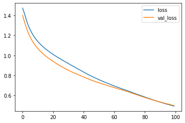

```python
#Plotlossperiteration
plt.plot(r.history['loss'],label='loss')
plt.plot(r.history['val_loss'],label='val_loss')
plt.legend()
```

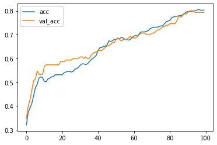

```python
#Plotaccuracyperiteration
plt.plot(r.history['accuracy'],label='acc')
plt.plot(r.history['val_accuracy'],label='val_acc')
plt.legend()
```

**MODEL-5**

```python
# Define the model
model = tf.keras.models.Sequential()

# Adding the first layer
model.add(tf.keras.layers.Dense(units=6, input_shape=[7],activation='relu'))

#Adding a second hidden layer
model.add(tf.keras.layers.Dense(units=6, activation='relu'))
#Adding dropout of 0.1
model.add(tf.keras.layers.Dropout(0.1))

#Adding a thied hidden layer
model.add(tf.keras.layers.Dense(units=6, activation='relu'))
#Adding dropout of 0.1
model.add(tf.keras.layers.Dropout(0.1))

#Adding an output layer
model.add(tf.keras.layers.Dense(units=4, activation='softmax'))

model.compile(optimizer='adam',
              loss='sparse_categorical_crossentropy',
              metrics=['accuracy'])

# Train the model
r = model.fit(X_train, y_train, validation_data=(X_test, y_test), epochs=100)

#Evaluatethemodel
print("\nModel Evaluation")
print(model.evaluate(X_test,y_test))
```

```
Model Evaluation
[0.35220661759376526, 0.8733333349227905]
```

[figure not shown]

```python
#Plotlossperiteration
plt.plot(r.history['loss'],label='loss')
plt.plot(r.history['val_loss'],label='val_loss')
plt.legend()
```

[figure not shown]

```python
#Plotaccuracyperiteration
plt.plot(r.history['accuracy'],label='acc')
plt.plot(r.history['val_accuracy'],label='val_acc')
plt.legend()
```

**Summary of Models**